# Nystroem

**class*sklearn.kernel_approximation.Nystroem(*kernel='rbf'*, *, *gamma=None*, *coef0=None*, *degree=None*, *kernel_params=None*, *n_components=100*, *random_state=None*, *n_jobs=None*)[[source]](https://github.com/scikit-learn/scikit-learn/blob/99bf3d8e4/sklearn/kernel_approximation.py#L839)**

Approximate a kernel map using a subset of the training data.

Constructs an approximate feature map for an arbitrary kernel using a subset of the data as basis.

Read more in the User Guide.

Added in version 0.13.

**Parameters:**

**kernel**str or callable, default=’rbf’**

Kernel map to be approximated. A callable should accept two arguments and the keyword arguments passed to this object as `kernel_params`, and should return a floating point number.

**gamma**float, default=None**

Gamma parameter for the RBF, laplacian, polynomial, exponential chi2 and sigmoid kernels. Interpretation of the default value is left to the kernel; see the documentation for sklearn.metrics.pairwise. Ignored by other kernels.

**coef0**float, default=None**

Zero coefficient for polynomial and sigmoid kernels. Ignored by other kernels.

**degree**float, default=None**

Degree of the polynomial kernel. Ignored by other kernels.

**kernel_params**dict, default=None**

Additional parameters (keyword arguments) for kernel function passed as callable object.

**n_components**int, default=100**

Number of features to construct. How many data points will be used to construct the mapping.

**random_state**int, RandomState instance or None, default=None**

Pseudo-random number generator to control the uniform sampling without replacement of `n_components` of the training data to construct the basis kernel. Pass an int for reproducible output across multiple function calls. See [Glossary](https://scikit-learn.org/1.6/glossary.html#term-random_state).

**n_jobs**int, default=None**

The number of jobs to use for the computation. This works by breaking down the kernel matrix into `n_jobs` even slices and computing them in parallel.

`None` means 1 unless in a [`joblib.parallel_backend`](https://joblib.readthedocs.io/en/latest/generated/joblib.parallel_backend.html#joblib.parallel_backend) context. `-1` means using all processors. See [Glossary](https://scikit-learn.org/1.6/glossary.html#term-n_jobs) for more details.

Added in version 0.24.

**Attributes:**

**components_**ndarray of shape (n_components, n_features)**

Subset of training points used to construct the feature map.

**component_indices_**ndarray of shape (n_components)**

Indices of `components_` in the training set.

**normalization_**ndarray of shape (n_components, n_components)**

Normalization matrix needed for embedding. Square root of the kernel matrix on `components_`.

**n_features_in_**int**

Number of features seen during fit.

Added in version 0.24.

**feature_names_in_**ndarray of shape (`n_features_in_`,)**

Names of features seen during fit. Defined only when `X` has feature names that are all strings.

Added in version 1.0.

See also

**`AdditiveChi2Sampler`**

Approximate feature map for additive chi2 kernel.

**`PolynomialCountSketch`**

Polynomial kernel approximation via Tensor Sketch.

**`RBFSampler`**

Approximate a RBF kernel feature map using random Fourier features.

**`SkewedChi2Sampler`**

Approximate feature map for “skewed chi-squared” kernel.

**`sklearn.metrics.pairwise.kernel_metrics`**

List of built-in kernels.

#### References

- Williams, C.K.I. and Seeger, M. “Using the Nystroem method to speed up kernel machines”, Advances in neural information processing systems 2001
- T. Yang, Y. Li, M. Mahdavi, R. Jin and Z. Zhou “Nystroem Method vs Random Fourier Features: A Theoretical and Empirical Comparison”, Advances in Neural Information Processing Systems 2012

#### Examples

```
>>> from sklearn import datasets, svm
>>> from sklearn.kernel_approximation import Nystroem
>>> X, y = datasets.load_digits(n_class=9, return_X_y=True)
>>> data = X / 16.
>>> clf = svm.LinearSVC()
>>> feature_map_nystroem = Nystroem(gamma=.2,
...                                 random_state=1,
...                                 n_components=300)
>>> data_transformed = feature_map_nystroem.fit_transform(data)
>>> clf.fit(data_transformed, y)
LinearSVC()
>>> clf.score(data_transformed, y)
0.9987...
```

**fit(*X*, *y=None*)[[source]](https://github.com/scikit-learn/scikit-learn/blob/99bf3d8e4/sklearn/kernel_approximation.py#L990)**

Fit estimator to data.

Samples a subset of training points, computes kernel on these and computes normalization matrix.

**Parameters:**

**X**array-like, shape (n_samples, n_features)**

Training data, where `n_samples` is the number of samples and `n_features` is the number of features.

**y**array-like, shape (n_samples,) or (n_samples, n_outputs), default=None**

Target values (None for unsupervised transformations).

**Returns:**

**self**object**

Returns the instance itself.

**fit_transform(*X*, *y=None*, **fit_params)[[source]](https://github.com/scikit-learn/scikit-learn/blob/99bf3d8e4/sklearn/base.py#L863)**

Fit to data, then transform it.

Fits transformer to `X` and `y` with optional parameters `fit_params` and returns a transformed version of `X`.

**Parameters:**

**X**array-like of shape (n_samples, n_features)**

Input samples.

**y**array-like of shape (n_samples,) or (n_samples, n_outputs), default=None**

Target values (None for unsupervised transformations).

**fit_paramsdict**

Additional fit parameters.

**Returns:**

**X_new**ndarray array of shape (n_samples, n_features_new)**

Transformed array.

**get_feature_names_out(*input_features=None*)[[source]](https://github.com/scikit-learn/scikit-learn/blob/99bf3d8e4/sklearn/base.py#L995)**

Get output feature names for transformation.

The feature names out will prefixed by the lowercased class name. For example, if the transformer outputs 3 features, then the feature names out are: `["class_name0", "class_name1", "class_name2"]`.

**Parameters:**

**input_features**array-like of str or None, default=None**

Only used to validate feature names with the names seen in `fit`.

**Returns:**

**feature_names_out**ndarray of str objects**

Transformed feature names.

**get_metadata_routing()[[source]](https://github.com/scikit-learn/scikit-learn/blob/99bf3d8e4/sklearn/utils/_metadata_requests.py#L1497)**

Get metadata routing of this object.

Please check [User Guide](https://scikit-learn.org/1.6/metadata_routing.html#metadata-routing) on how the routing mechanism works.

**Returns:**

**routing**MetadataRequest**

A `MetadataRequest` encapsulating routing information.

**get_params(*deep=True*)[[source]](https://github.com/scikit-learn/scikit-learn/blob/99bf3d8e4/sklearn/base.py#L231)**

Get parameters for this estimator.

**Parameters:**

**deep**bool, default=True**

If True, will return the parameters for this estimator and contained subobjects that are estimators.

**Returns:**

**params**dict**

Parameter names mapped to their values.

**set_output(*, *transform=None*)[[source]](https://github.com/scikit-learn/scikit-learn/blob/99bf3d8e4/sklearn/utils/_set_output.py#L392)**

Set output container.

See Introducing the set_output API for an example on how to use the API.

**Parameters:**

**transform**{“default”, “pandas”, “polars”}, default=None**

Configure output of `transform` and `fit_transform`.

- `"default"`: Default output format of a transformer
- `"pandas"`: DataFrame output
- `"polars"`: Polars output
- `None`: Transform configuration is unchanged

Added in version 1.4: `"polars"` option was added.

**Returns:**

**self**estimator instance**

Estimator instance.

**set_params(**params)[[source]](https://github.com/scikit-learn/scikit-learn/blob/99bf3d8e4/sklearn/base.py#L255)**

Set the parameters of this estimator.

The method works on simple estimators as well as on nested objects (such as `Pipeline`). The latter have parameters of the form `<component>__<parameter>` so that it’s possible to update each component of a nested object.

**Parameters:**

**paramsdict**

Estimator parameters.

**Returns:**

**self**estimator instance**

Estimator instance.

**transform(*X*)[[source]](https://github.com/scikit-learn/scikit-learn/blob/99bf3d8e4/sklearn/kernel_approximation.py#L1050)**

Apply feature map to X.

Computes an approximate feature map using the kernel between some training points and X.

**Parameters:**

**X**array-like of shape (n_samples, n_features)**

Data to transform.

**Returns:**

**X_transformed**ndarray of shape (n_samples, n_components)**

Transformed data.

## Gallery examples

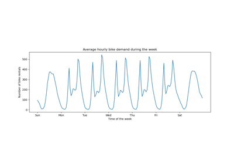

Time-related feature engineering

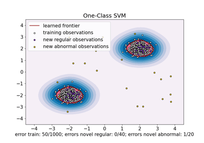

One-Class SVM versus One-Class SVM using Stochastic Gradient Descent

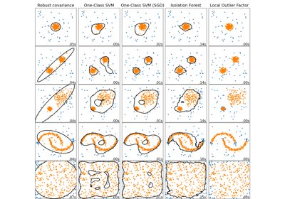

Comparing anomaly detection algorithms for outlier detection on toy datasets

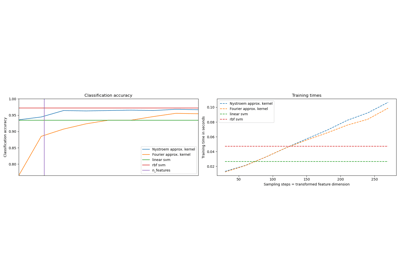

Explicit feature map approximation for RBF kernels

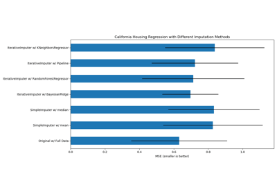

Imputing missing values with variants of IterativeImputer